# Data Analysis School: FORECASTING METHODS AND APPLICATIONS WITH R

Cristina Amado / UMinho

## Plan of the course

1. Introduction to Forecasting
2. Regression Analysis and Forecasting
3. Exponential Smoothing Methods
4. Univariate Time Series Models
5. Trend and Seasonality
6. Forecasting Volatility

### Setup

```r
knitr::opts_chunk$set(warning = FALSE, echo = TRUE)
# install.packages('pacman')  # Package Management Tool
#install.packages('fpp3', dependencies = TRUE)
rm(list=ls())
library(here)
library(pacman)
start_time <- Sys.time()  # calcular o tempo de execução do programa
# setwd("/Users/miguelportela/Documents/GitHub/R_Training/timeseries/Code")
# setwd('D:\\miguel\\Dropbox\\1.miguel\\1.formacao\\r\\forecasting\\2.Lecture_Code\\_2021')
# setwd('D:\\miguel\\Dropbox\\Modelação e Análise de Dados com R - Módulo 8\\Code')
setwd('C:\\Users\\mangelo.EEG\\Documents\\GitHub\\R_Training\\timeseries\\Code')
getwd()
```

```
## [1] "C:/Users/mangelo.EEG/Documents/GitHub/R_Training/timeseries/Code"
```

```r
# CHECK: `fpp3` package https://pkg.robjhyndman.com/fpp3-package/

pacman::p_load(here,
        tidyverse,
        haven,
        #xlsx,
        #readxl,
        ggplot2,
        AER,
        fpp3,
        TSA,
        forecast,
        fma,
        expsmooth,
        lmtest,
        tseries,
        gdata,
        foreign,
        pacman,
        urca)
```

### Lecture 1.a

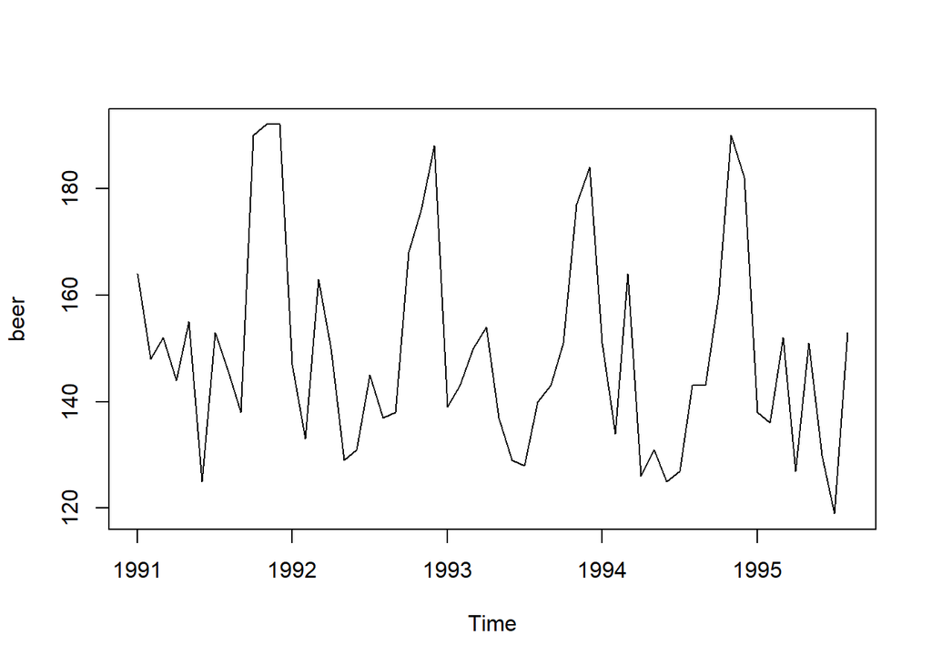

```r
# data: gold, tempdub, sales, google, oil.price, wages, larain
# data("beer",package="fma")
plot(beer,type = "l")
```

### Lecture 1.b

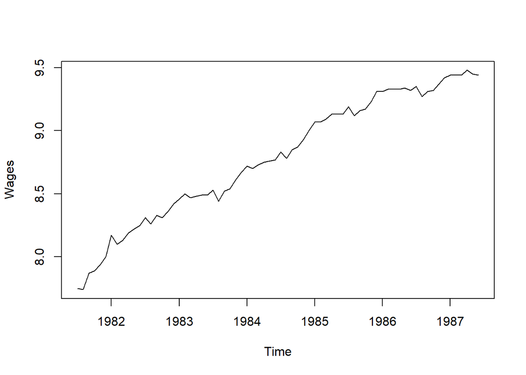

```r
data(wages) # ?TSA (Cryer, J. D. Time Series Analysis, Duxbury Press, 1986.)

plot(wages,type = "l")
```

```r
mydata <- read.xls("sunspot.xlsx", 1)
# print(mydata)
#mydata2 = read.xls("sunspot.xlsx", sheet = 1, header = TRUE)
```

```r
# Sunspots: a temporary phenomena on the Sun’s photosphere that appear darker than the surrounding areas
# Sunspots appear on an 11-year solar cycle, so we should expect to see a seasonality component to the data

sunspot <- as.ts(mydata$Sunspot)
postscript(file="sunspot.eps", paper="special", width=10, height=7, horizontal=FALSE)
plot(sunspot ~ Year, mydata, type = "l")
```

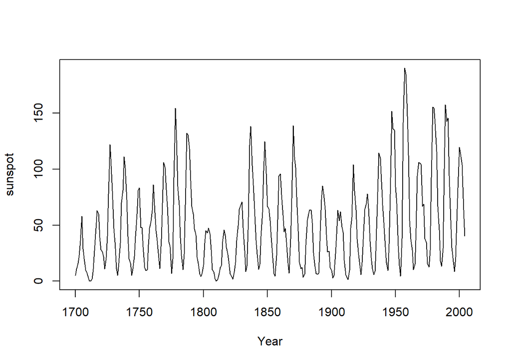

```r
plot(sunspot ~ Year, mydata, type = "l")
```

### Lecture 2.a

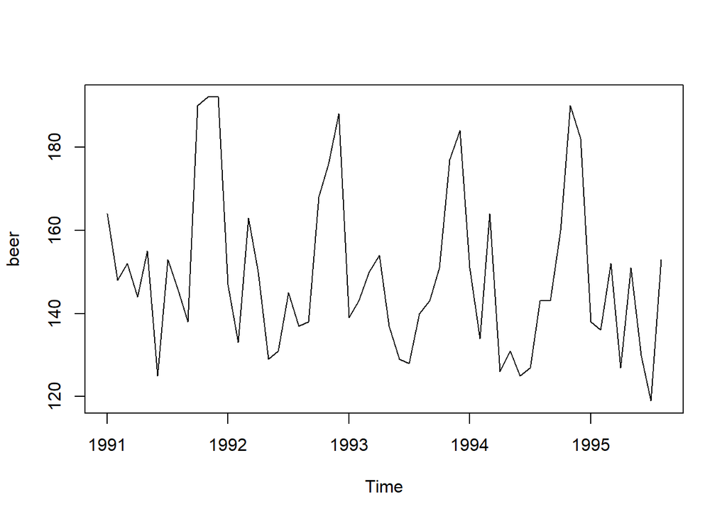

```r
# data("beer", package = "fma")
plot(beer,type = "l")
```

> 80% and 95% forecast interval: level=c(80,95)

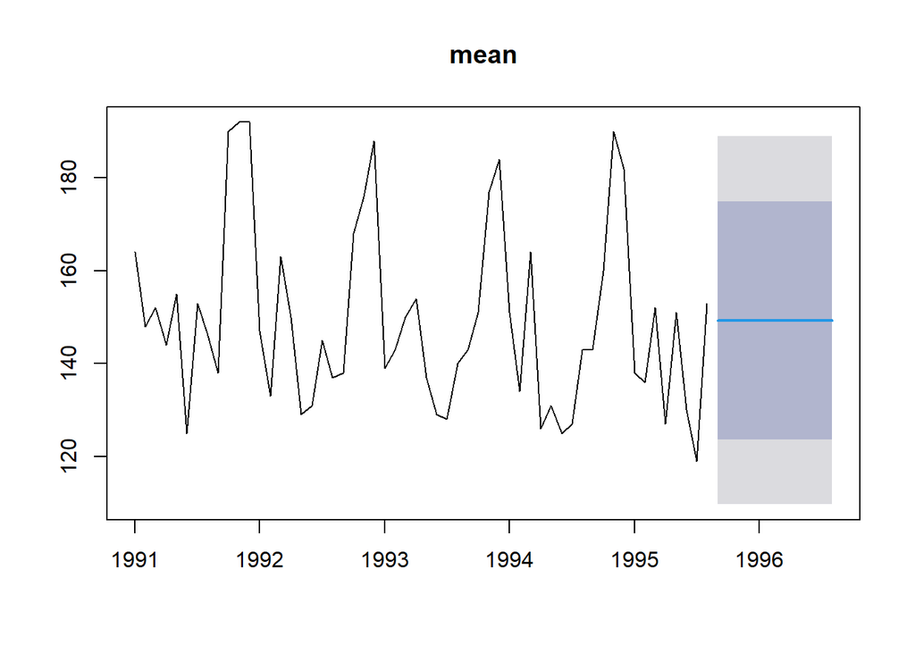

```r
beerfor1 <- meanf(beer, h=12)
plot(beerfor1, main="mean")
```

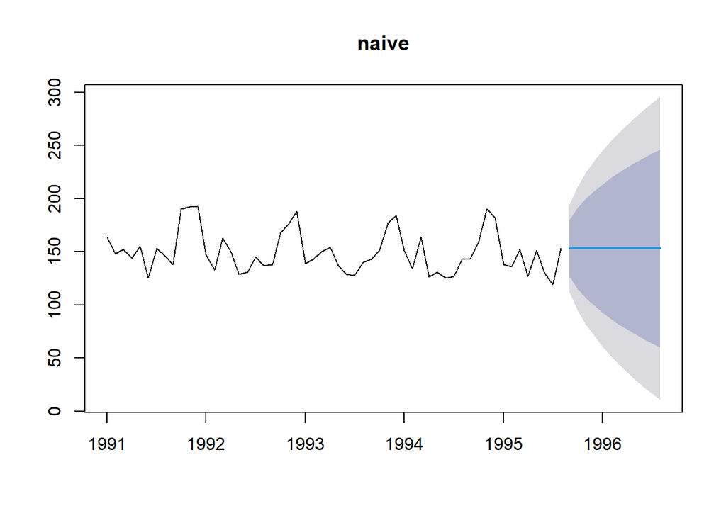

```r
beerfor2 <- naive(beer, h=12)
plot(beerfor2, main="naive")
```

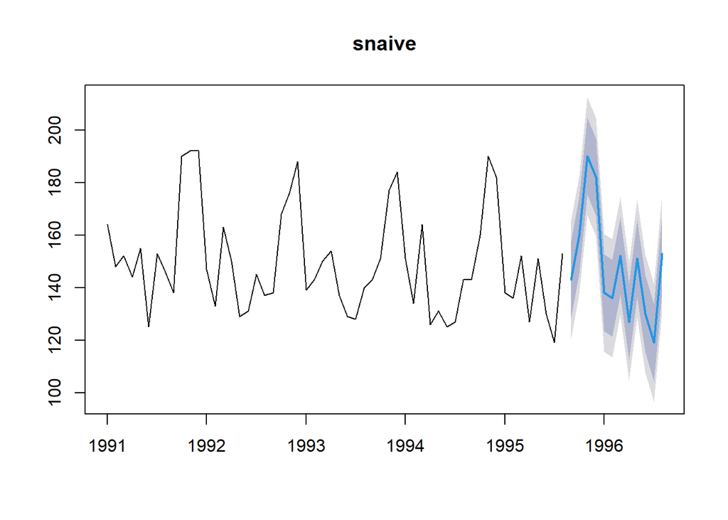

```r
beerfor3 <- snaive(beer, h=12)
plot(beerfor3, main="snaive")
```

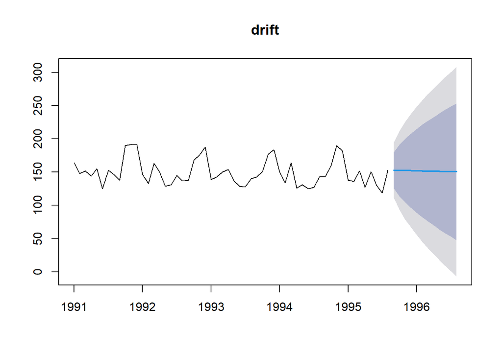

```r
beerfor4 <- rwf(beer, drift=TRUE, h=12)
plot(beerfor4, main="drift")
```

```r
#plot(forecast(beerfor4,level=c(80,95)))
summary(beerfor1)
```

```
##
## Forecast method: Mean
##
## Model Information:
## $mu
## [1] 149.3036
##
## $mu.se
## [1] 2.619596
##
## $sd
## [1] 19.60326
##
## $bootstrap
## [1] FALSE
##
## $call
## meanf(y = beer, h = 12)
##
## attr(,"class")
## [1] "meanf"
##
## Error measures:
##                       ME     RMSE     MAE       MPE     MAPE     MASE      ACF1
## Training set 1.21808e-14 19.42745 15.3361 -1.586682 10.12517 1.670268 0.4207789
##
## Forecasts:
##          Point Forecast    Lo 80    Hi 80    Lo 95    Hi 95
## Sep 1995       149.3036 123.6495 174.9577 109.6685 188.9386
## Oct 1995       149.3036 123.6495 174.9577 109.6685 188.9386
## Nov 1995       149.3036 123.6495 174.9577 109.6685 188.9386
## Dec 1995       149.3036 123.6495 174.9577 109.6685 188.9386
## Jan 1996       149.3036 123.6495 174.9577 109.6685 188.9386
## Feb 1996       149.3036 123.6495 174.9577 109.6685 188.9386
## Mar 1996       149.3036 123.6495 174.9577 109.6685 188.9386
## Apr 1996       149.3036 123.6495 174.9577 109.6685 188.9386
## May 1996       149.3036 123.6495 174.9577 109.6685 188.9386
## Jun 1996       149.3036 123.6495 174.9577 109.6685 188.9386
## Jul 1996       149.3036 123.6495 174.9577 109.6685 188.9386
## Aug 1996       149.3036 123.6495 174.9577 109.6685 188.9386
```

```r
summary(beerfor2)
```

```
##
## Forecast method: Naive method
##
## Model Information:
## Call: naive(y = beer, h = 12)
##
## Residual sd: 21
##
## Error measures:
##                ME RMSE      MAE       MPE     MAPE     MASE      ACF1
## Training set -0.2   21 16.16364 -1.088528 10.90629 1.760396 -0.172757
##
## Forecasts:
##          Point Forecast     Lo 80    Hi 80     Lo 95    Hi 95
## Sep 1995            153 126.08742 179.9126 111.84076 194.1592
## Oct 1995            153 114.93986 191.0601  94.79204 211.2080
## Nov 1995            153 106.38604 199.6140  81.71010 224.2899
## Dec 1995            153  99.17483 206.8252  70.68151 235.3185
## Jan 1996            153  92.82164 213.1784  60.96513 245.0349
## Feb 1996            153  87.07790 218.9221  52.18085 253.8191
## Mar 1996            153  81.79600 224.2040  44.10288 261.8971
## Apr 1996            153  76.87972 229.1203  36.58408 269.4159
## May 1996            153  72.26225 233.7377  29.52227 276.4777
## Jun 1996            153  67.89494 238.1051  22.84304 283.1570
## Jul 1996            153  63.74106 242.2589  16.49023 289.5098
## Aug 1996            153  59.77208 246.2279  10.42020 295.5798
```

```r
accuracy(beerfor1)
```

```
##                       ME     RMSE     MAE       MPE     MAPE     MASE      ACF1
## Training set 1.21808e-14 19.42745 15.3361 -1.586682 10.12517 1.670268 0.4207789
```

```r
accuracy(beerfor2)
```

```
##                ME RMSE      MAE       MPE     MAPE     MASE      ACF1
## Training set -0.2   21 16.16364 -1.088528 10.90629 1.760396 -0.172757
```

```r
accuracy(beerfor3)
```

```
##                     ME     RMSE      MAE       MPE     MAPE MASE      ACF1
## Training set -2.681818 11.43956 9.181818 -2.064328 6.332352    1 -0.141297
```

```r
accuracy(beerfor4)
```

```
##                         ME     RMSE      MAE      MPE     MAPE     MASE
## Training set -9.560219e-15 20.99905 16.18909 -0.95219 10.91464 1.763168
##                   ACF1
## Training set -0.172757
```

### Lecture 2.b

> Use 250 observations in the in-sample period

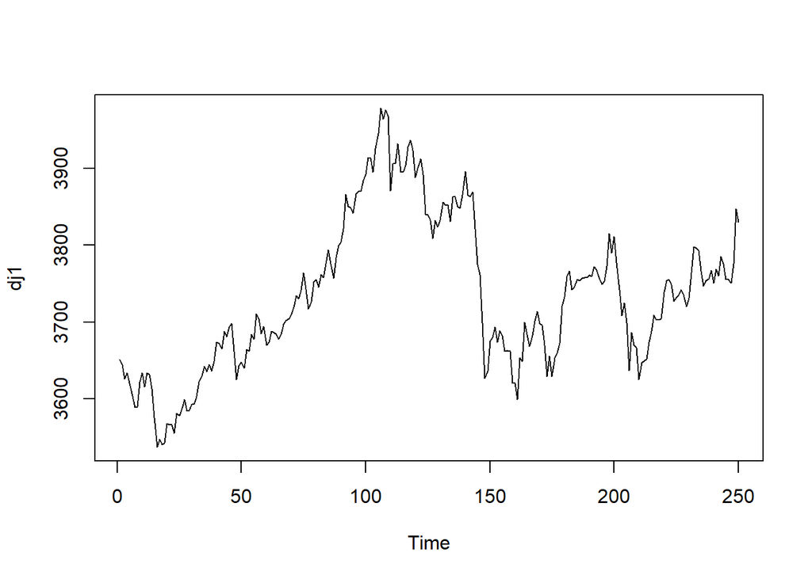

```r
dj1 <- window(dj, end=250)
plot(dj1)
```

#Out-of-sample period from 251 until 292

```r
dj2 <- window(dj, start=251)
```

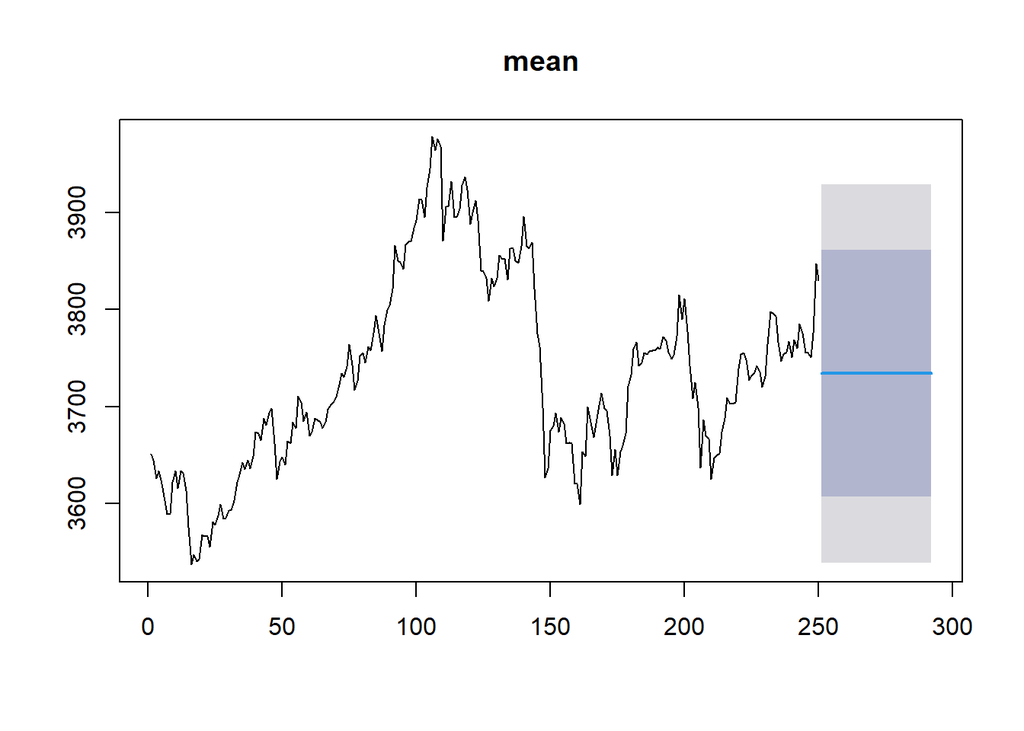

```r
#80% and 95% forecast interval: level=c(80,95)
djfor1 <- meanf(dj1, h=42)
plot(djfor1, main="mean")
```

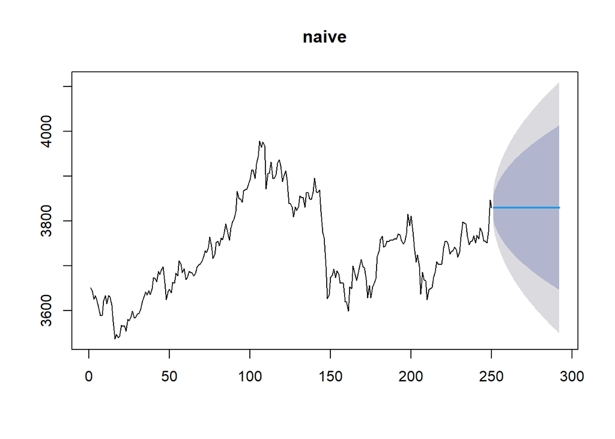

```r
djfor2 <- naive(dj1, h=42)
plot(djfor2, main="naive")
```

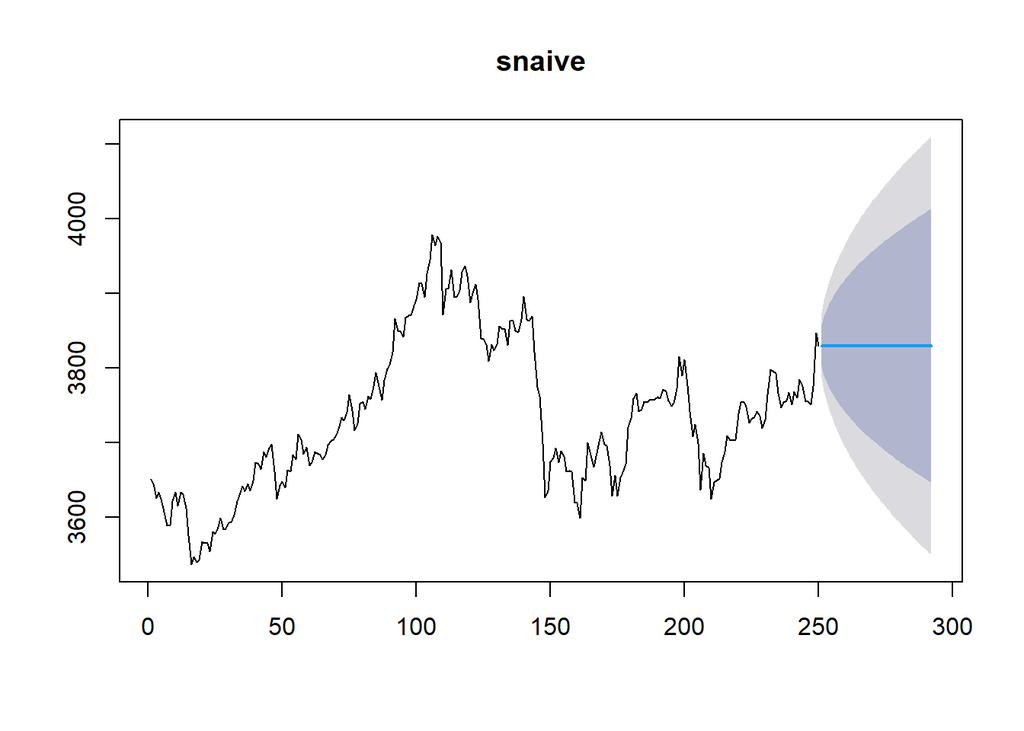

```r
djfor3 <- snaive(dj1, h=42)
plot(djfor3, main="snaive")
```

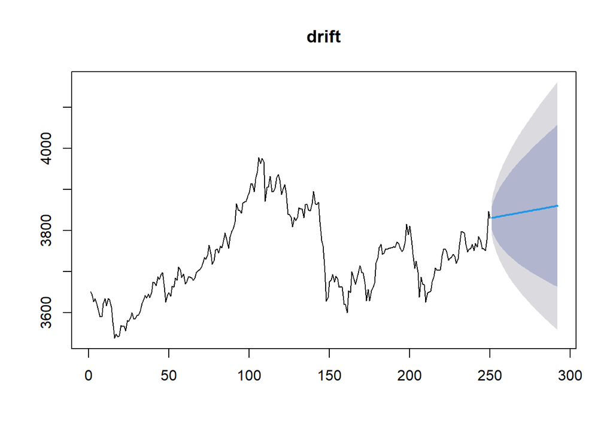

```r
djfor4 <- rwf(dj1, drift=TRUE, h=42)
plot(djfor4, main="drift")
```

> measures of forecast accuracy

```r
accuracy(meanf(dj1,h=42), dj2)
```

```
##                        ME      RMSE       MAE         MPE     MAPE     MASE
## Training set 6.553874e-14  98.71439  80.56688 -0.06934572 2.151962 4.920567
## Test set     1.424185e+02 148.23574 142.41848  3.66304611 3.663046 8.698111
##                   ACF1 Theil's U
## Training set 0.9719593        NA
## Test set     0.8255136  6.072223
```

```r
accuracy(naive(dj1,h=42), dj2)
```

```
##                      ME     RMSE      MAE        MPE      MAPE     MASE
## Training set  0.7188755 22.00014 16.37349 0.01749683 0.4380973 1.000000
## Test set     46.4404762 62.02846 54.44048 1.18683463 1.3979371 3.324915
##                    ACF1 Theil's U
## Training set 0.02446257        NA
## Test set     0.82551365   2.54582
```

```r
accuracy(snaive(dj1,h=42), dj2)
```

```
##                      ME     RMSE      MAE        MPE      MAPE     MASE
## Training set  0.7188755 22.00014 16.37349 0.01749683 0.4380973 1.000000
## Test set     46.4404762 62.02846 54.44048 1.18683463 1.3979371 3.324915
##                    ACF1 Theil's U
## Training set 0.02446257        NA
## Test set     0.82551365   2.54582
```

```r
accuracy(rwf(dj1,drift=TRUE,h=42), dj2)
```

```
##                        ME     RMSE      MAE          MPE      MAPE      MASE
## Training set 1.278395e-13 21.98839 16.34525 -0.001766862 0.4373707 0.9982752
## Test set     3.098465e+01 53.69767 45.72743  0.787547945 1.1757748 2.7927719
##                    ACF1 Theil's U
## Training set 0.02446257        NA
## Test set     0.83881869  2.203742
```

### Lecture 2.c

```r
# download.file('http://fmwww.bc.edu/ec-p/data/wooldridge/hprice1.dta','hprice1.dta',mode='wb')
hprice <- read.dta('hprice1.dta')
```

> Some statistics

```r
  summary(hprice)
```

```
##      price           assess          bdrms          lotsize          sqrft
##  Min.   :111.0   Min.   :198.7   Min.   :2.000   Min.   : 1000   Min.   :1171
##  1st Qu.:230.0   1st Qu.:253.9   1st Qu.:3.000   1st Qu.: 5733   1st Qu.:1660
##  Median :265.5   Median :290.2   Median :3.000   Median : 6430   Median :1845
##  Mean   :293.5   Mean   :315.7   Mean   :3.568   Mean   : 9020   Mean   :2014
##  3rd Qu.:326.2   3rd Qu.:352.1   3rd Qu.:4.000   3rd Qu.: 8583   3rd Qu.:2227
##  Max.   :725.0   Max.   :708.6   Max.   :7.000   Max.   :92681   Max.   :3880
##     colonial          lprice         lassess         llotsize
##  Min.   :0.0000   Min.   :4.710   Min.   :5.292   Min.   : 6.908
##  1st Qu.:0.0000   1st Qu.:5.438   1st Qu.:5.537   1st Qu.: 8.654
##  Median :1.0000   Median :5.582   Median :5.671   Median : 8.769
##  Mean   :0.6932   Mean   :5.633   Mean   :5.718   Mean   : 8.905
##  3rd Qu.:1.0000   3rd Qu.:5.788   3rd Qu.:5.864   3rd Qu.: 9.058
##  Max.   :1.0000   Max.   :6.586   Max.   :6.563   Max.   :11.437
##      lsqrft
##  Min.   :7.066
##  1st Qu.:7.415
##  Median :7.520
##  Mean   :7.573
##  3rd Qu.:7.708
##  Max.   :8.264
```

```r
  cor(hprice)
```

```
##              price     assess     bdrms    lotsize      sqrft   colonial
## price    1.0000000 0.90527938 0.5080835 0.34712448 0.78790655 0.13794578
## assess   0.9052794 1.00000000 0.4824739 0.32814633 0.86563447 0.08293582
## bdrms    0.5080835 0.48247394 1.0000000 0.13632563 0.53147364 0.30457549
## lotsize  0.3471245 0.32814633 0.1363256 1.00000000 0.18384224 0.01401865
## sqrft    0.7879065 0.86563447 0.5314736 0.18384224 1.00000000 0.06542126
## colonial 0.1379458 0.08293582 0.3045755 0.01401865 0.06542126 1.00000000
## lprice   0.9665014 0.86823970 0.4634897 0.32455387 0.76400002 0.18051612
## lassess  0.8731444 0.98296161 0.4587439 0.30990708 0.86621376 0.10997230
## llotsize 0.5287804 0.57166539 0.1694902 0.80785523 0.33860720 0.03864210
## lsqrft   0.7503026 0.84718487 0.5195793 0.16487038 0.98581609 0.10628626
##             lprice   lassess  llotsize    lsqrft
## price    0.9665014 0.8731444 0.5287804 0.7503026
## assess   0.8682397 0.9829616 0.5716654 0.8471849
## bdrms    0.4634897 0.4587439 0.1694902 0.5195793
## lotsize  0.3245539 0.3099071 0.8078552 0.1648704
## sqrft    0.7640000 0.8662138 0.3386072 0.9858161
## colonial 0.1805161 0.1099723 0.0386421 0.1062863
## lprice   1.0000000 0.8750037 0.5041425 0.7436335
## lassess  0.8750037 1.0000000 0.5577345 0.8646644
## llotsize 0.5041425 0.5577345 1.0000000 0.3112993
## lsqrft   0.7436335 0.8646644 0.3112993 1.0000000
```

```r
  cor(hprice$price,hprice$sqrft)
```

```
## [1] 0.7879065
```

> OLS estimation single regression

```r
lm.r <- lm(price ~ sqrft, data = hprice)
summary(lm.r)
```

```
##
## Call:
## lm(formula = price ~ sqrft, data = hprice)
##
## Residuals:
##      Min       1Q   Median       3Q      Max
## -117.112  -36.348   -6.503   31.701  235.253
##
## Coefficients:
##             Estimate Std. Error t value Pr(>|t|)
## (Intercept) 11.20415   24.74261   0.453    0.652
## sqrft        0.14021    0.01182  11.866   <2e-16 ***
## ---
## Signif. codes:  0 '***' 0.001 '**' 0.01 '*' 0.05 '.' 0.1 ' ' 1
##
## Residual standard error: 63.62 on 86 degrees of freedom
## Multiple R-squared:  0.6208, Adjusted R-squared:  0.6164
## F-statistic: 140.8 on 1 and 86 DF,  p-value: < 2.2e-16
```

> Residuals

```r
resid(lm.r) #lm.r$res
```

```
##            1            2            3            4            5            6
##  -53.0385077   67.7178661  -12.8540278  -19.2296402    9.3054580   68.9298174
##            7            8            9           10           11           12
##   31.4797649   61.0906533  -52.9569419  -36.2028921  -53.7369880  -80.5198592
##           13           14           15           16           17           18
##  -79.4161934  -65.4647909  -70.3719245  -30.5754712  -51.6260996   25.0615812
##           19           20           21           22           23           24
##   63.8655502   41.5087116  -32.3562265  -39.0122608  -34.0971529 -104.0495577
##           25           26           27           28           29           30
##   33.8920477   -7.0917532  -52.0917532   36.5115368  -28.5086839   51.2231405
##           31           32           33           34           35           36
##   -1.7560123  -72.8609998   11.2519620  -34.1923433   60.1199759  -59.8432284
##           37           38           39           40           41           42
##  -36.7843326   19.7772631  -62.1542899   14.5560562    1.7652107  235.2530896
##           43           44           45           46           47           48
##    4.6064766   54.6088005   42.2920840    6.4636910  -86.3081302 -117.1117233
##           49           50           51           52           53           54
##   26.4317938   74.1302742  -23.7001923   36.5640305    1.3787989  -85.2664359
##           55           56           57           58           59           60
##   -2.6474479  -10.7796846  -36.9173210  -12.5944530    7.8897237  -23.7184648
##           61           62           63           64           65           66
##   -5.9147465   21.4847887  104.4634404   93.1137274   -1.6338233  113.9192969
##           67           68           69           70           71           72
##   -0.2081666    5.7896347  -66.0356825  -13.7189660  -33.7215406   13.4317938
##           73           74           75           76           77           78
##  200.3432561  -24.6104016  -14.3693500  203.1989671   68.9980375   12.2946586
##           79           80           81           82           83           84
##  -35.5309093   32.3628503 -115.4279952  -20.6968801  -60.2450876   26.2282897
##           85           86           87           88
##  -15.6659711  -29.3962233   41.6458469  -17.9384188
```

> Predicted values

```r
fitted(lm.r) #lm.r$fit
```

```
##        1        2        3        4        5        6        7        8
## 353.0385 302.2821 203.8540 214.2296 363.6945 397.3452 301.0202 253.9093
##        9       10       11       12       13       14       15       16
## 258.9569 276.2029 338.7370 380.5199 484.4162 277.4648 335.3719 257.9755
##       17       18       19       20       21       22       23       24
## 291.6261 259.9384 204.1344 268.4913 298.3562 309.0123 259.0972 254.0496
##       25       26       27       28       29       30       31       32
## 213.1080 282.0918 282.0918 306.4885 506.0087 298.7769 231.7560 407.8610
##       33       34       35       36       37       38       39       40
## 239.7480 269.1923 300.8800 249.8432 396.7843 555.2227 271.1553 210.4439
##       41       42       43       44       45       46       47       48
## 244.2348 478.2469 243.3935 175.3912 332.7079 258.5363 399.3081 534.6117
##       49       50       51       52       53       54       55       56
## 226.5682 240.8697 287.7002 218.4360 208.6212 265.2664 252.6474 260.7797
##       57       58       59       60       61       62       63       64
## 245.9173 270.5945 281.1103 339.7185 230.9147 244.5152 205.5366 378.1363
##       65       66       67       68       69       70       71       72
## 336.6338 381.0807 279.7082 374.2104 391.0357 233.7190 248.7215 226.5682
##       73       74       75       76       77       78       79       80
## 524.6567 254.6104 320.3693 221.8010 249.0020 317.7053 281.5309 192.6371
##       81       82       83       84       85       86       87       88
## 226.4280 288.8219 304.2451 268.7717 251.6660 231.8962 177.3542 259.9384
```

> Scatterplot with fitted line

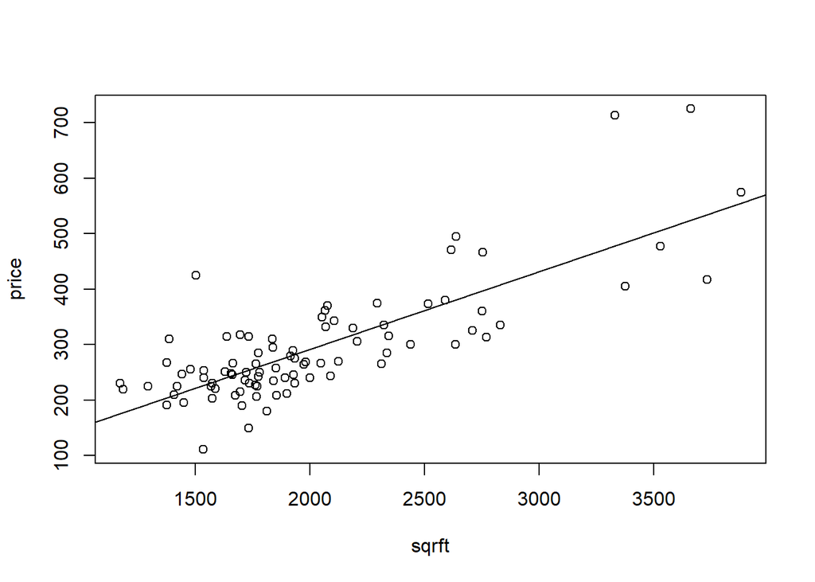

```r
plot(price ~ sqrft, hprice)
abline(lm.r)
```

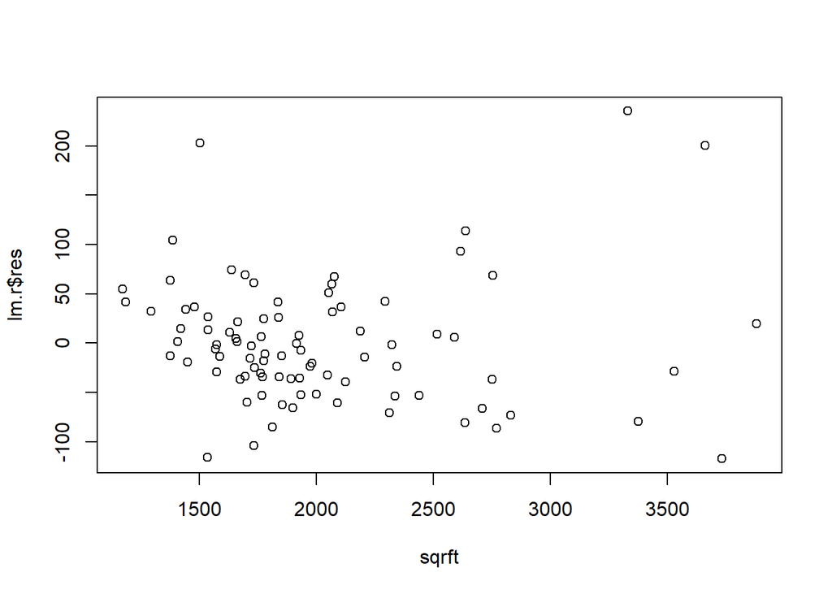

```r
plot(lm.r$res ~ sqrft, hprice)
```

> Regression with logs between lprice and lsqrft

```r
lm.r4 <- lm(lprice ~ lsqrft, data = hprice)
summary(lm.r4)
```

```
##
## Call:
## lm(formula = lprice ~ lsqrft, data = hprice)
##
## Residuals:
##      Min       1Q   Median       3Q      Max
## -0.71742 -0.12714 -0.01056  0.12371  0.64410
##
## Coefficients:
##             Estimate Std. Error t value Pr(>|t|)
## (Intercept)  -0.9751     0.6411  -1.521    0.132
## lsqrft        0.8727     0.0846  10.315   <2e-16 ***
## ---
## Signif. codes:  0 '***' 0.001 '**' 0.01 '*' 0.05 '.' 0.1 ' ' 1
##
## Residual standard error: 0.2041 on 86 degrees of freedom
## Multiple R-squared:  0.553,  Adjusted R-squared:  0.5478
## F-statistic: 106.4 on 1 and 86 DF,  p-value: < 2.2e-16
```

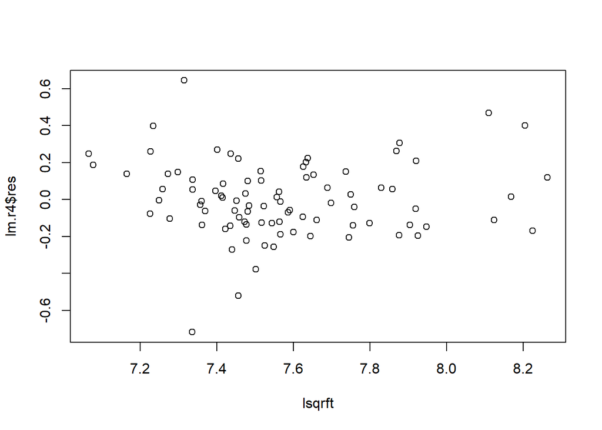

```r
plot(lm.r4$res ~ lsqrft, hprice)
```

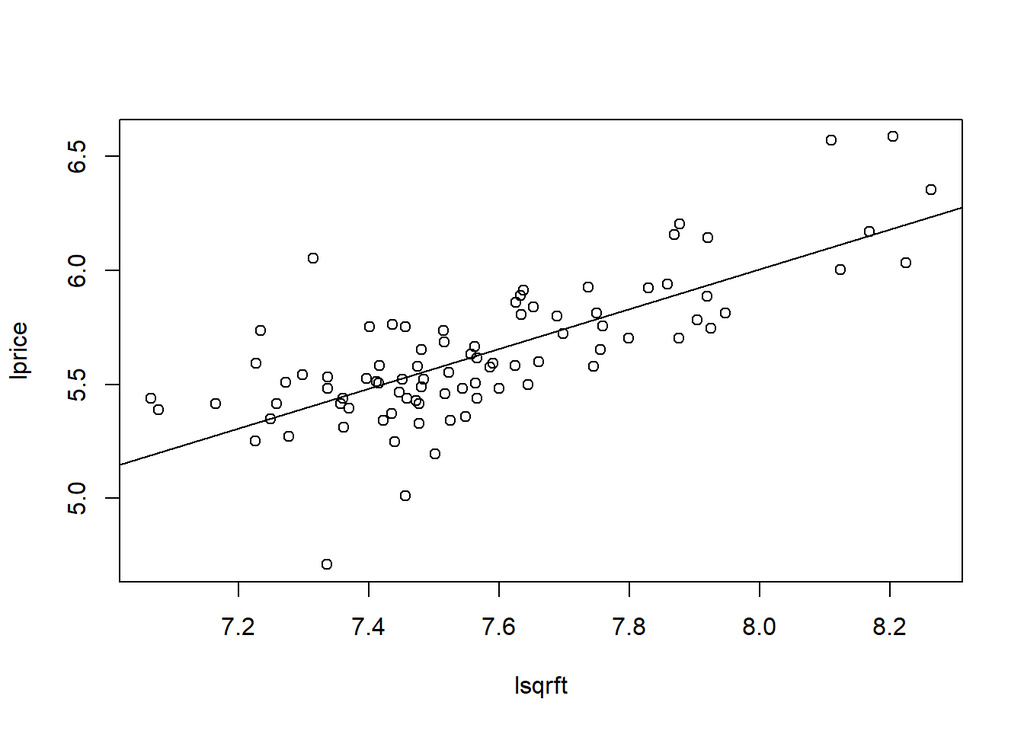

```r
plot(lprice ~ lsqrft, hprice)
abline(lm.r4)
```

> Regression with logs between lprice and lassess

```r
lm.r5 <- lm(lprice ~ lassess, data = hprice)
summary(lm.r5)
```

```
##
## Call:
## lm(formula = lprice ~ lassess, data = hprice)
##
## Residuals:
##      Min       1Q   Median       3Q      Max
## -0.51044 -0.08257 -0.00496  0.08033  0.60799
##
## Coefficients:
##             Estimate Std. Error t value Pr(>|t|)
## (Intercept) -0.16147    0.34607  -0.467    0.642
## lassess      1.01341    0.06046  16.761   <2e-16 ***
## ---
## Signif. codes:  0 '***' 0.001 '**' 0.01 '*' 0.05 '.' 0.1 ' ' 1
##
## Residual standard error: 0.1478 on 86 degrees of freedom
## Multiple R-squared:  0.7656, Adjusted R-squared:  0.7629
## F-statistic: 280.9 on 1 and 86 DF,  p-value: < 2.2e-16
```

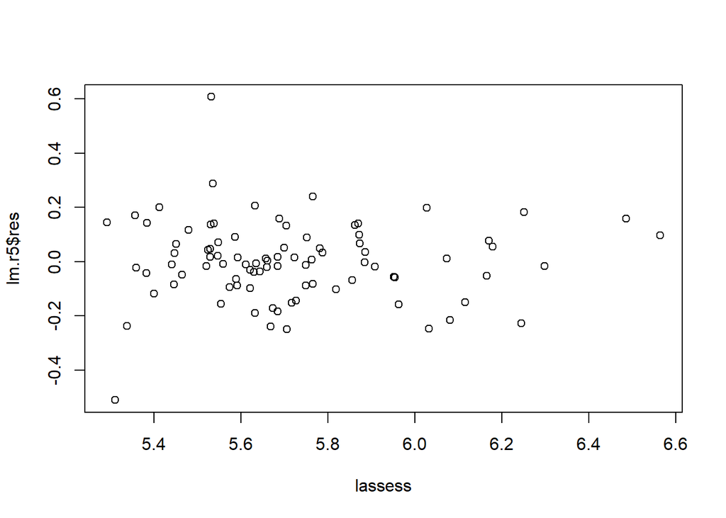

```r
plot(lm.r5$res ~ lassess, hprice)
```

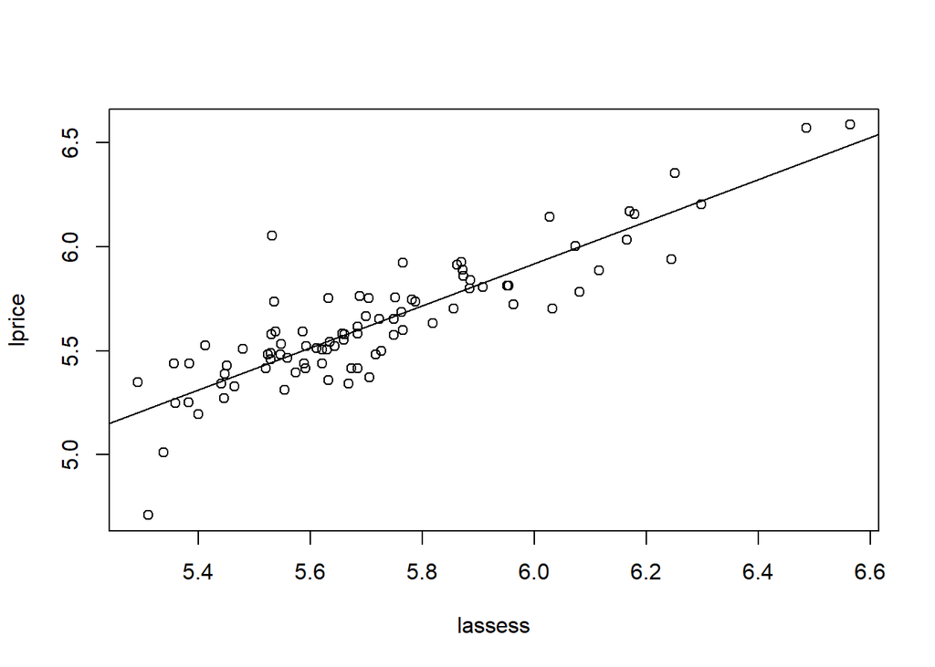

```r
plot(lprice ~ lassess, hprice)
abline(lm.r5)
```

> Confidence intervals for the coefficients

```r
confint(lm.r5,level=0.95)
```

```
##                  2.5 %    97.5 %
## (Intercept) -0.8494464 0.5264978
## lassess      0.8932147 1.1335992
```

> Prediction interval for a single observation

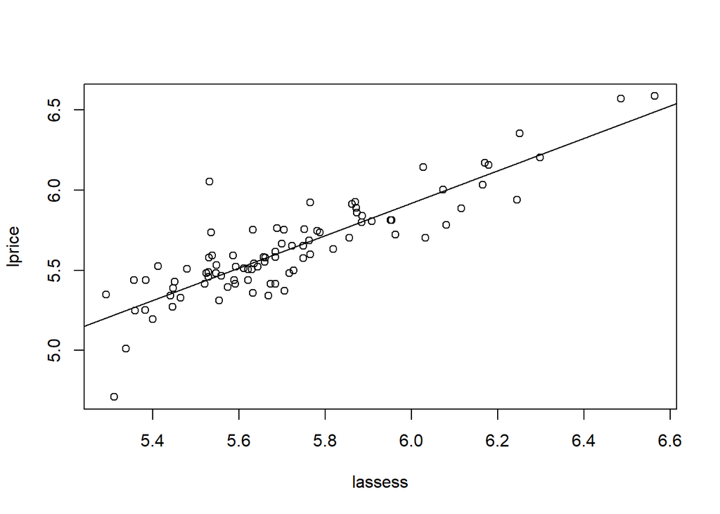

```r
plot(lprice ~ lassess, hprice)
abline(lm.r5)
```

```r
newdata = data.frame(lassess=250)
```

> Interval estimate on the mean at a specific point

```r
con.1 <- predict(lm.r5, newdata, level = 0.90, interval="confidence")
# lines(newdata,con.1[,c("lwr","upr")],col="red",lty=1,type="l")
newdata = data.frame(lassess=250)
```

> Interval estimate on a single future observation

```r
pred.1 <- predict(lm.r5, newdata, level = 0.90, interval="predict")
# lines(newdata,pred.1[,c("lwr","upr")],col="blue",lty=1,type="l")
```

> Plot prediction interval

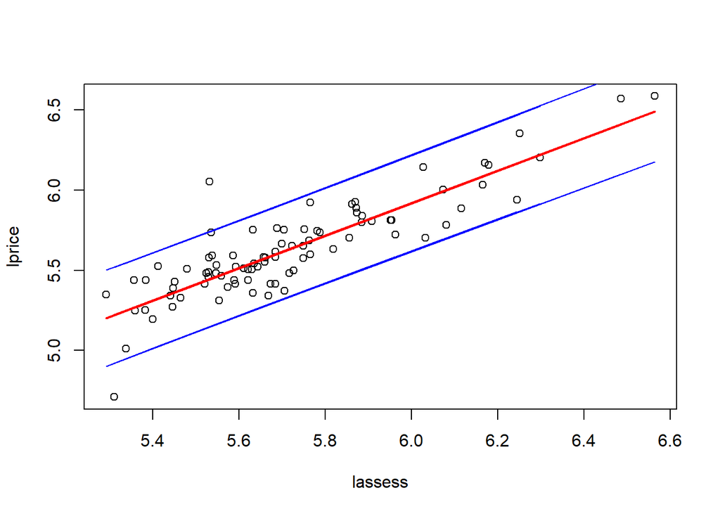

```r
conf.2 <- predict(lm.r5, level = 0.95, interval="confidence")
pred.2 <- predict(lm.r5, level = 0.95, interval="predict")
fitted = pred.2[,1]
pred.lower = pred.2[,2]
pred.upper = pred.2[,3]
plot(lprice ~ lassess, hprice)
lines(hprice$lassess,fitted,col="red",lwd=2)
lines(hprice$lassess,pred.lower,lwd=1,col="blue")
lines(hprice$lassess,pred.upper,lwd=1,col="blue")
```

> OLS estimation multiple regression

```r
lm.r2 <- lm(price ~ sqrft + bdrms, data = hprice)
summary(lm.r2)
```

```
##
## Call:
## lm(formula = price ~ sqrft + bdrms, data = hprice)
##
## Residuals:
##      Min       1Q   Median       3Q      Max
## -127.627  -42.876   -7.051   32.589  229.003
##
## Coefficients:
##              Estimate Std. Error t value Pr(>|t|)
## (Intercept) -19.31500   31.04662  -0.622    0.536
## sqrft         0.12844    0.01382   9.291 1.39e-14 ***
## bdrms        15.19819    9.48352   1.603    0.113
## ---
## Signif. codes:  0 '***' 0.001 '**' 0.01 '*' 0.05 '.' 0.1 ' ' 1
##
## Residual standard error: 63.04 on 85 degrees of freedom
## Multiple R-squared:  0.6319, Adjusted R-squared:  0.6233
## F-statistic: 72.96 on 2 and 85 DF,  p-value: < 2.2e-16
```

> OLS estimation multiple regression

```r
lm.r3 <- lm(lprice ~ lsqrft + llotsize, data = hprice)
summary(lm.r3)
```

```
##
## Call:
## lm(formula = lprice ~ lsqrft + llotsize, data = hprice)
##
## Residuals:
##      Min       1Q   Median       3Q      Max
## -0.65332 -0.11051 -0.00648  0.11822  0.66417
##
## Coefficients:
##             Estimate Std. Error t value Pr(>|t|)
## (Intercept) -1.64007    0.60188  -2.725  0.00781 **
## lsqrft       0.76237    0.08089   9.425 7.44e-15 ***
## llotsize     0.16846    0.03846   4.380 3.37e-05 ***
## ---
## Signif. codes:  0 '***' 0.001 '**' 0.01 '*' 0.05 '.' 0.1 ' ' 1
##
## Residual standard error: 0.1855 on 85 degrees of freedom
## Multiple R-squared:  0.6353, Adjusted R-squared:  0.6267
## F-statistic: 74.04 on 2 and 85 DF,  p-value: < 2.2e-16
```

### Lecture 2.d

```r
download.file('http://fmwww.bc.edu/ec-p/data/wooldridge/wage1.dta','wage1.dta',mode='wb')
wage <- read.dta('wage1.dta')
```

```r
fit.r <- lm(lwage ~ educ + exper, data = wage)
summary(fit.r)
```

```
##
## Call:
## lm(formula = lwage ~ educ + exper, data = wage)
##
## Residuals:
##      Min       1Q   Median       3Q      Max
## -2.05800 -0.30136 -0.04539  0.30601  1.44425
##
## Coefficients:
##             Estimate Std. Error t value Pr(>|t|)
## (Intercept) 0.216854   0.108595   1.997   0.0464 *
## educ        0.097936   0.007622  12.848  < 2e-16 ***
## exper       0.010347   0.001555   6.653 7.24e-11 ***
## ---
## Signif. codes:  0 '***' 0.001 '**' 0.01 '*' 0.05 '.' 0.1 ' ' 1
##
## Residual standard error: 0.4614 on 523 degrees of freedom
## Multiple R-squared:  0.2493, Adjusted R-squared:  0.2465
## F-statistic: 86.86 on 2 and 523 DF,  p-value: < 2.2e-16
```

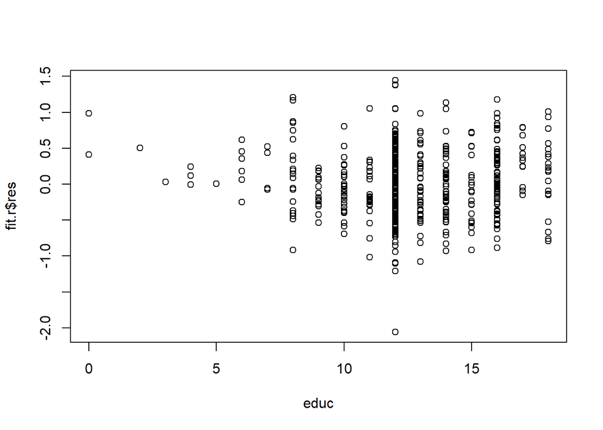

```r
plot(fit.r$res ~ educ, wage)
```

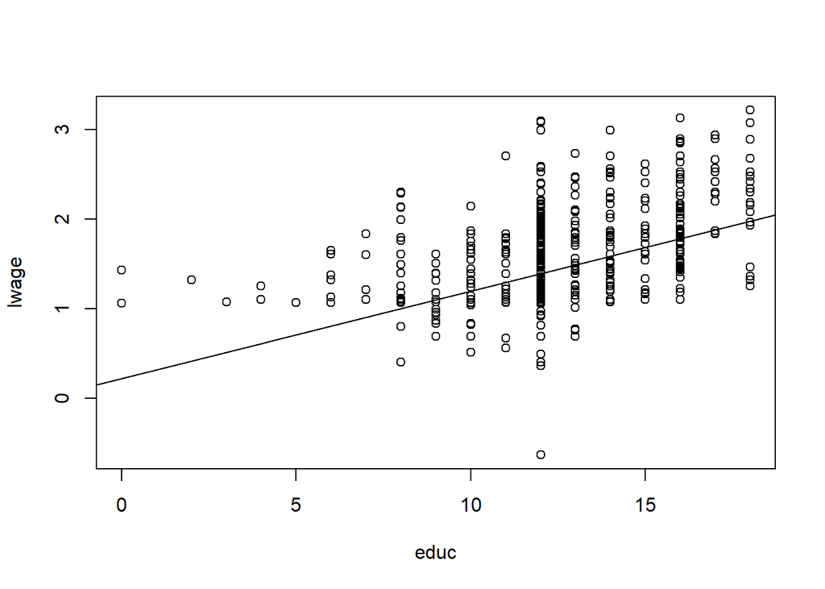

```r
plot(lwage ~ educ, wage)
abline(fit.r)
```

> Coefficients

```r
fit.r$coef #(or coef(fit.r))
```

```
## (Intercept)        educ       exper
##  0.21685433  0.09793557  0.01034695
```

> Residuals

```r
# fit.r$res
```

> Predicted values

```r
# fit.r$fit
```

> Prediction interval for a single observation

```r
newdata = data.frame(educ=12, exper=5)
```

> Interval estimate on the mean at a specific point

```r
predict(fit.r, newdata, level = 0.95, interval="confidence")
```

```
##        fit      lwr      upr
## 1 1.443816 1.387547 1.500085
```

> Interval estimate on a single future observation

```r
predict(fit.r, newdata, level = 0.95, interval="predict")
```

```
##        fit       lwr      upr
## 1 1.443816 0.5356328 2.351999
```

> Prediction interval for several observations

```r
neweduc=c(12,15,16)
newexper=c(5,7,10)
predict(fit.r,data.frame(educ = neweduc,exper=newexper),
        level = 0.95, interval = "predict")
```

```
##        fit       lwr      upr
## 1 1.443816 0.5356328 2.351999
## 2 1.758317 0.8501361 2.666497
## 3 1.887293 0.9786455 2.795940
```

### Lecture 3.0

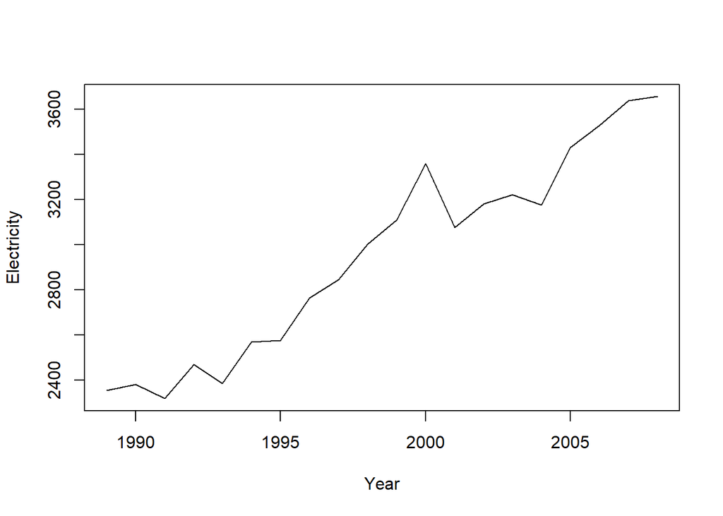

```r
data(elecsales, package = "fpp")
plot(elecsales,ylab="Electricity", xlab="Year")
```

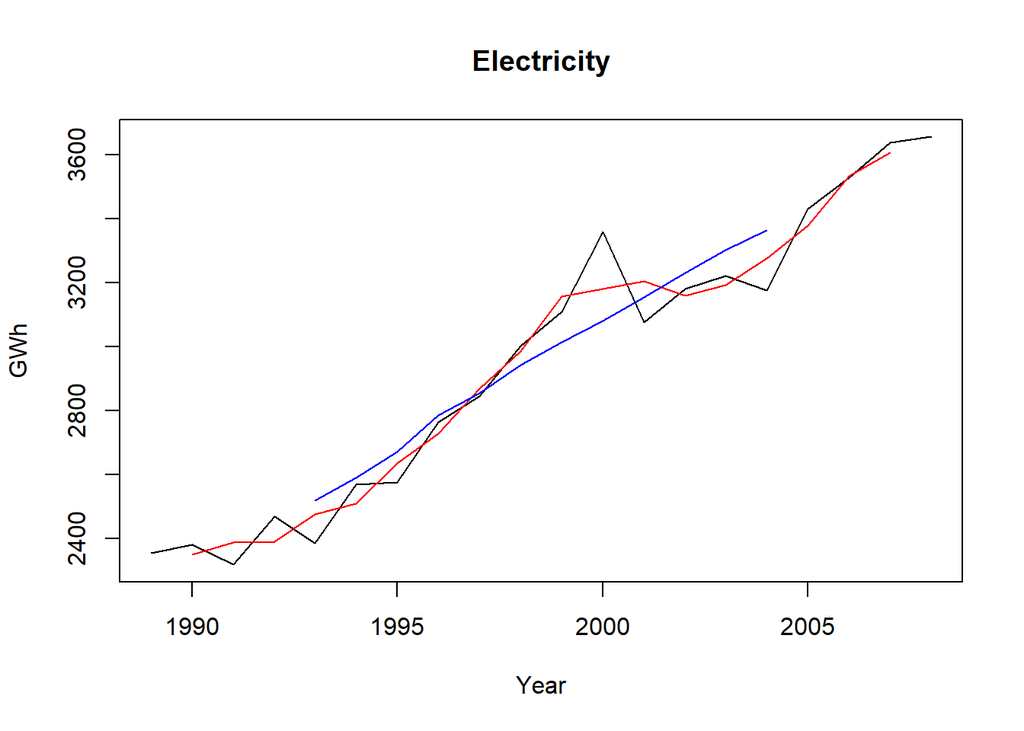

```r
ma.1 <- ma(elecsales,order=5)
plot(elecsales, main="Electricity",
     ylab="GWh", xlab="Year")
lines(ma(elecsales,3),col="red")
lines(ma(elecsales,9),col="blue")
```

```r
print(ma.1)
```

```
## Time Series:
## Start = 1989
## End = 2008
## Frequency = 1
##  [1]       NA       NA 2381.530 2424.556 2463.758 2552.598 2627.700 2750.622
##  [9] 2858.348 3014.704 3077.300 3144.520 3188.700 3202.320 3216.940 3307.296
## [17] 3398.754 3485.434       NA       NA
```

```r
print(elecsales)
```

```
## Time Series:
## Start = 1989
## End = 2008
## Frequency = 1
##  [1] 2354.34 2379.71 2318.52 2468.99 2386.09 2569.47 2575.72 2762.72 2844.50
## [10] 3000.70 3108.10 3357.50 3075.70 3180.60 3221.60 3176.20 3430.60 3527.48
## [19] 3637.89 3655.00
```

### Lecture 3.a

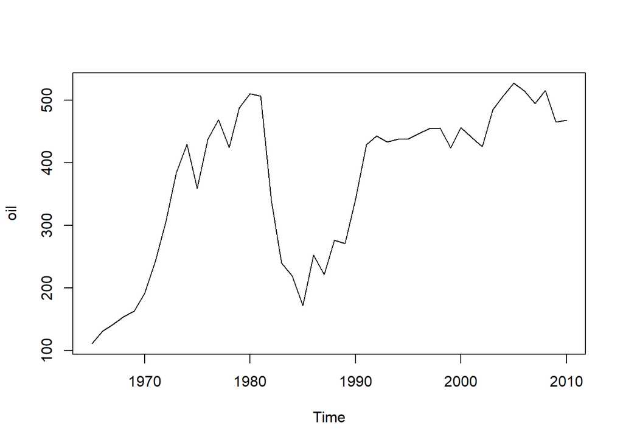

```r
data(oil, package = "fpp")
plot(oil)
```

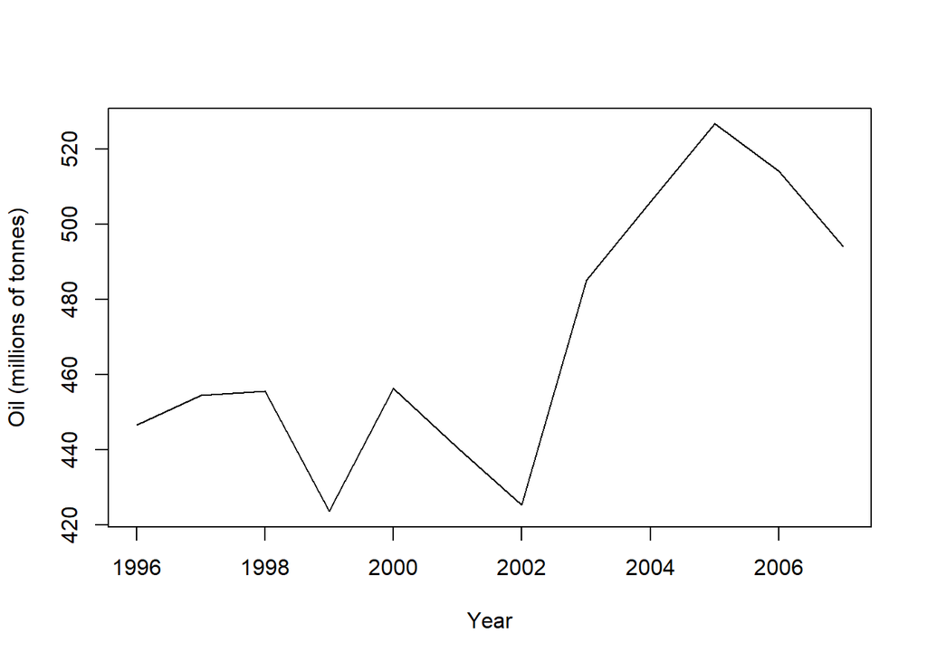

```r
oildata <- window(oil,start=1996,end=2007)
plot(oildata, ylab="Oil (millions of tonnes)", xlab="Year")
```

> Simple exponential smoothing

```r
# lo=y1 or initial=optimal

fit1 <- ses(oildata, alpha=0.2, initial="simple", h=3)

fit2 <- ses(oildata, alpha=0.6, initial="simple", h=3)

fit3 <- ses(oildata, alpha=0.89, initial="simple", h=3)
```

> Plot for alpha=0.2,0.6,0.89

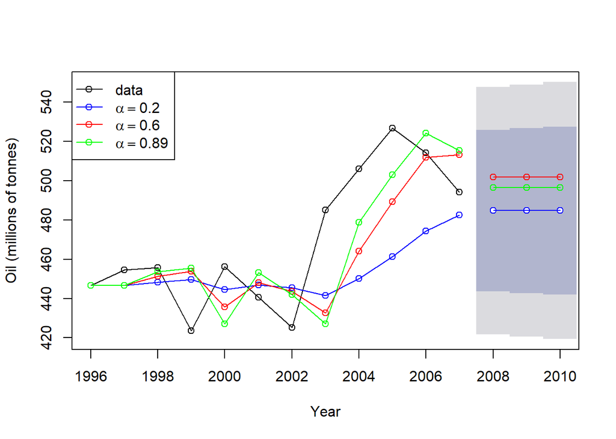

```r
plot(fit1, plot.conf=FALSE, ylab="Oil (millions of tonnes)",
     xlab="Year", main="", fcol="white", type="o")
lines(fitted(fit1), col="blue", type="o")
lines(fitted(fit2), col="red", type="o")
lines(fitted(fit3), col="green", type="o")
lines(fit1$mean, col="blue", type="o")
lines(fit2$mean, col="red", type="o")
lines(fit3$mean, col="green", type="o")
legend("topleft",lty=1, col=c(1,"blue","red","green"),
       c("data", expression(alpha == 0.2), expression(alpha == 0.6),
         expression(alpha == 0.89)),pch=1)
```

```r
oildata
```

```
## Time Series:
## Start = 1996
## End = 2007
## Frequency = 1
##  [1] 446.6565 454.4733 455.6630 423.6322 456.2713 440.5881 425.3325 485.1494
##  [9] 506.0482 526.7920 514.2689 494.2110
```

> Level lt for each alpha

```r
fit1$model$state
```

```
## Time Series:
## Start = 1995
## End = 2007
## Frequency = 1
##              l
##  [1,] 446.6565
##  [2,] 446.6565
##  [3,] 448.2199
##  [4,] 449.7085
##  [5,] 444.4932
##  [6,] 446.8489
##  [7,] 445.5967
##  [8,] 441.5439
##  [9,] 450.2650
## [10,] 461.4216
## [11,] 474.4957
## [12,] 482.4503
## [13,] 484.8025
```

```r
fit2$model$state
```

```
## Time Series:
## Start = 1995
## End = 2007
## Frequency = 1
##              l
##  [1,] 446.6565
##  [2,] 446.6565
##  [3,] 451.3466
##  [4,] 453.9364
##  [5,] 435.7539
##  [6,] 448.0644
##  [7,] 443.5786
##  [8,] 432.6309
##  [9,] 464.1420
## [10,] 489.2857
## [11,] 511.7895
## [12,] 513.2771
## [13,] 501.8375
```

```r
fit3$model$state
```

```
## Time Series:
## Start = 1995
## End = 2007
## Frequency = 1
##              l
##  [1,] 446.6565
##  [2,] 446.6565
##  [3,] 453.6135
##  [4,] 455.4375
##  [5,] 427.1308
##  [6,] 453.0659
##  [7,] 441.9606
##  [8,] 427.1616
##  [9,] 478.7708
## [10,] 503.0477
## [11,] 524.1801
## [12,] 515.3591
## [13,] 496.5373
```

```r
fitted(fit1)
```

```
## Time Series:
## Start = 1996
## End = 2007
## Frequency = 1
##  [1] 446.6565 446.6565 448.2199 449.7085 444.4932 446.8489 445.5967 441.5439
##  [9] 450.2650 461.4216 474.4957 482.4503
```

```r
fitted(fit2)
```

```
## Time Series:
## Start = 1996
## End = 2007
## Frequency = 1
##  [1] 446.6565 446.6565 451.3466 453.9364 435.7539 448.0644 443.5786 432.6309
##  [9] 464.1420 489.2857 511.7895 513.2771
```

```r
fitted(fit3)
```

```
## Time Series:
## Start = 1996
## End = 2007
## Frequency = 1
##  [1] 446.6565 446.6565 453.6135 455.4375 427.1308 453.0659 441.9606 427.1616
##  [9] 478.7708 503.0477 524.1801 515.3591
```

> Summary of results

```r
summary(fit1)
```

```
##
## Forecast method: Simple exponential smoothing
##
## Model Information:
## Simple exponential smoothing
##
## Call:
##  ses(y = oildata, h = 3, initial = "simple", alpha = 0.2)
##
##   Smoothing parameters:
##     alpha = 0.2
##
##   Initial states:
##     l = 446.6565
##
##   sigma:  32.1348
## Error measures:
##                    ME    RMSE      MAE      MPE     MAPE     MASE      ACF1
## Training set 15.89414 32.1348 24.66102 3.010684 5.067472 1.136664 0.5102479
##
## Forecasts:
##      Point Forecast    Lo 80    Hi 80    Lo 95    Hi 95
## 2008       484.8025 443.6201 525.9849 421.8194 547.7855
## 2009       484.8025 442.8045 526.8004 420.5721 549.0328
## 2010       484.8025 442.0045 527.6005 419.3486 550.2564
```

```r
summary(fit2)
```

```
##
## Forecast method: Simple exponential smoothing
##
## Model Information:
## Simple exponential smoothing
##
## Call:
##  ses(y = oildata, h = 3, initial = "simple", alpha = 0.6)
##
##   Smoothing parameters:
##     alpha = 0.6
##
##   Initial states:
##     l = 446.6565
##
##   sigma:  25.9784
## Error measures:
##                    ME     RMSE      MAE      MPE     MAPE      MASE      ACF1
## Training set 7.664019 25.97844 20.17946 1.406176 4.239181 0.9301025 0.1642665
##
## Forecasts:
##      Point Forecast    Lo 80    Hi 80    Lo 95    Hi 95
## 2008       501.8375 468.5447 535.1302 450.9206 552.7543
## 2009       501.8375 463.0118 540.6631 442.4588 561.2162
## 2010       501.8375 458.1745 545.5004 435.0607 568.6142
```

```r
summary(fit3)
```

```
##
## Forecast method: Simple exponential smoothing
##
## Model Information:
## Simple exponential smoothing
##
## Call:
##  ses(y = oildata, h = 3, initial = "simple", alpha = 0.89)
##
##   Smoothing parameters:
##     alpha = 0.89
##
##   Initial states:
##     l = 446.6565
##
##   sigma:  25.1233
## Error measures:
##                    ME     RMSE      MAE       MPE     MAPE      MASE
## Training set 4.670486 25.12328 19.99891 0.8292433 4.238524 0.9217804
##                     ACF1
## Training set -0.03760481
##
## Forecasts:
##      Point Forecast    Lo 80    Hi 80    Lo 95    Hi 95
## 2008       496.5373 464.3405 528.7341 447.2966 545.7780
## 2009       496.5373 453.4357 539.6389 430.6191 562.4555
## 2010       496.5373 444.7796 548.2951 417.3806 575.6940
```

### Lecture 3.b

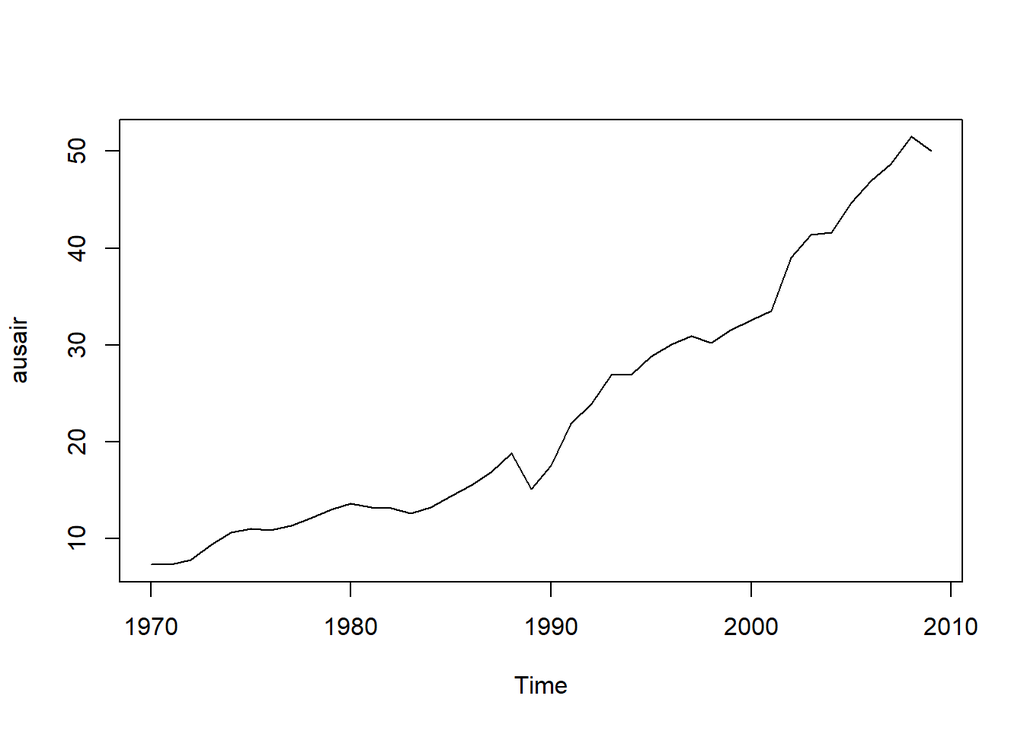

```r
data(ausair, package = "fpp")
#original data - from 1970 until 2010
plot(ausair)
```

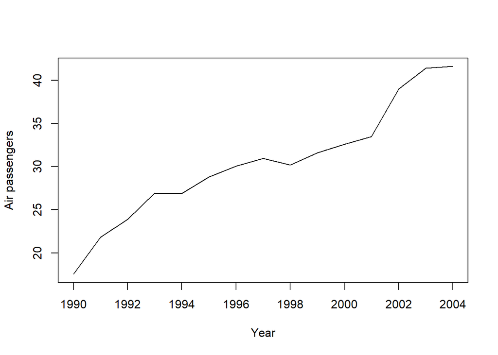

```r
air <- window(ausair,start=1990,end=2004)
fit1 <- holt(air, alpha=0.8, beta=0.2, initial="simple", h=5)
fit2 <- holt(air, alpha=0.8, beta=0.2, initial="simple", exponential=TRUE, h=5)
# fit3 <- holt(air, alpha=0.8, beta=0.2, damped=TRUE, initial="simple", h=5)
plot(air,ylab="Air passengers", xlab="Year")
```

```r
air
```

```
## Time Series:
## Start = 1990
## End = 2004
## Frequency = 1
##  [1] 17.55340 21.86010 23.88660 26.92930 26.88850 28.83140 30.07510 30.95350
##  [9] 30.18570 31.57970 32.57757 33.47740 39.02158 41.38643 41.59655
```

```r
#print(air)
```

> Results for first model

```r
#level lt and trend bt
fit1$model$state
```

```
## Time Series:
## Start = 1989
## End = 2004
## Frequency = 1
##             l        b
## 1989 17.55340 4.306700
## 1990 18.41474 3.617628
## 1991 21.89455 3.590065
## 1992 24.20620 3.334382
## 1993 27.05156 3.236576
## 1994 27.56843 2.692635
## 1995 29.11733 2.463889
## 1996 30.37632 2.222910
## 1997 31.28265 1.959592
## 1998 30.79701 1.470546
## 1999 31.71727 1.360489
## 2000 32.67761 1.280459
## 2001 33.57353 1.203552
## 2002 38.17268 1.882672
## 2003 41.12022 2.095644
## 2004 41.92041 1.836555
```

```r
#Fitted values (lt+bt)
fitted(fit1)
```

```
## Time Series:
## Start = 1990
## End = 2004
## Frequency = 1
##  [1] 21.86010 22.03237 25.48462 27.54059 30.28813 30.26106 31.58122 32.59923
##  [9] 33.24224 32.26755 33.07776 33.95807 34.77708 40.05535 43.21586
```

> Forecasts

```r
fit1$mean
```

```
## Time Series:
## Start = 2005
## End = 2009
## Frequency = 1
## [1] 43.75697 45.59352 47.43008 49.26663 51.10319
```

> Plots

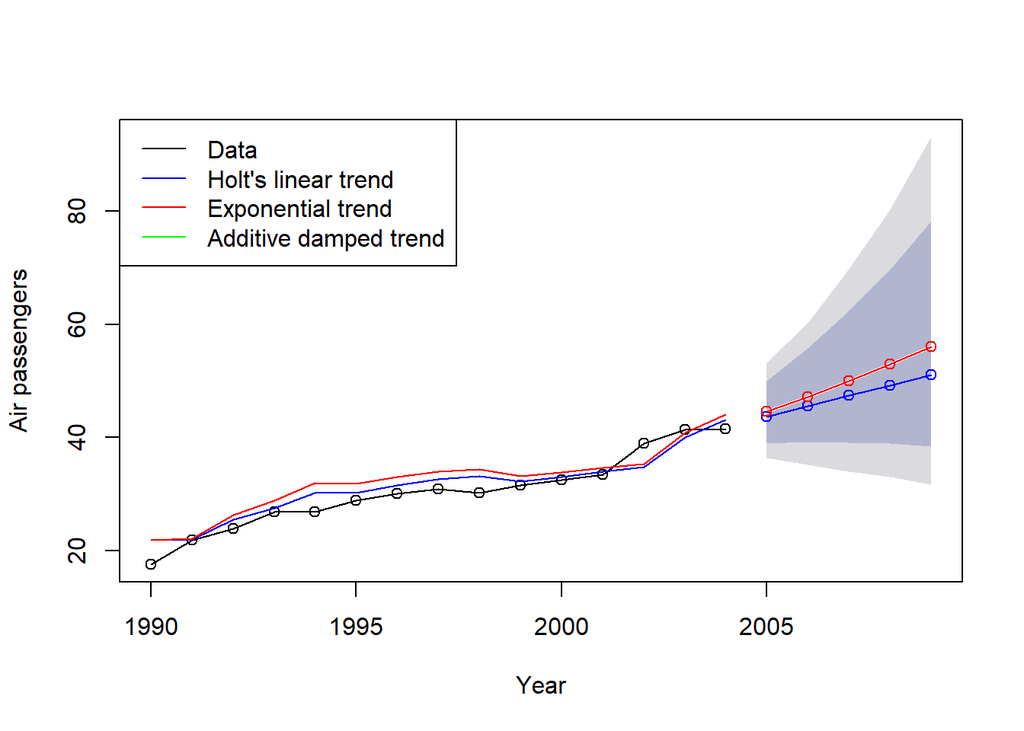

```r
plot(fit2, type="o", ylab="Air passengers", xlab="Year",
     fcol="white", plot.conf=FALSE, main="")
lines(fitted(fit1), col="blue")
lines(fitted(fit2), col="red")
lines(fitted(fit3), col="green")
lines(fit1$mean, col="blue", type="o")
lines(fit2$mean, col="red", type="o")
lines(fit3$mean, col="green", type="o")
legend("topleft", lty=1, col=c("black","blue","red","green"),
       c("Data","Holt's linear trend","Exponential trend","Additive damped trend"))
```

> Forecast results

```r
summary(fit1)
```

```
##
## Forecast method: Holt's method
##
## Model Information:
## Holt's method
##
## Call:
##  holt(y = air, h = 5, initial = "simple", alpha = 0.8, beta = 0.2)
##
##   Smoothing parameters:
##     alpha = 0.8
##     beta  = 0.2
##
##   Initial states:
##     l = 17.5534
##     b = 4.3067
##
##   sigma:  2.2029
## Error measures:
##                     ME     RMSE      MAE       MPE     MAPE     MASE     ACF1
## Training set -1.029227 2.202869 1.772637 -4.485612 6.364749 0.967131 0.208894
##
## Forecasts:
##      Point Forecast    Lo 80    Hi 80    Lo 95    Hi 95
## 2005       43.75697 40.93388 46.58006 39.43943 48.07451
## 2006       45.59352 41.60107 49.58598 39.48760 51.69945
## 2007       47.43008 42.19403 52.66613 39.42223 55.43793
## 2008       49.26663 42.70637 55.82690 39.23357 59.29970
## 2009       51.10319 43.13827 59.06810 38.92190 63.28448
```

```r
summary(fit2)
```

[output not shown]

```r
summary(fit3)
```

[output not shown]